# Hustru eller enke

Laura Bundgaard Jørgensen

2026-11-05

##Indledende arbejde installerer de pakker jeg skal bruge

Jeg henter min database. den er delt med et ; og ikke , derfor bruger jeg csv2 funktionen og ikke kun csv.

```r
library(readr)
```

```r
df_enker <- read_csv2("/work/CulturalDataScience/Bachelor/Enker/df_enker.csv")
```

```
## ℹ Using "','" as decimal and "'.'" as grouping mark. Use `read_delim()` for more control.
```

```
## ──────────────────────────────────────────────────────── Delimiter: ";" chr
## (30): Fornavn, Efternavn, Født, Død, Periode, Kommentarer, Familie-Id, T... dbl
## (3): ID, antal_børn1, Længde_på_1 lgl (7): Overlevede_sin_3mand, gift4, ...33,
## ...34, ...35, ...37, ...39
```

## antallet af kvinder der giftede sig igen eller forblev enker. grafer for i alt og fordelt ud over de tre perioder.

```r
gee<-count(df_enker, Gift_eller_Enke) #tæller hvor mange der blev gift igen og hvor mange der blev enker og laver et dataframe med det

gee
```

```
## # A tibble: 2 × 2
##   Gift_eller_Enke     n
##   <chr>           <int>
## 1 Forblev_Enke       75
## 2 Gift_igen          34
```

FIND UD AF HVORDAN JEG TILFØJER EN I ALT KOLONNE til det ovenover

```r
#omregner det til procent. muterer min dataframe til at have en ny kolonne
gee_clean<-na.omit(gee)

gee_percentage<-gee_clean%>%
  mutate("I procent(%)"=round(n/sum(n)*100, 1))

gee_percentage
```

```
## # A tibble: 2 × 3
##   Gift_eller_Enke     n `I procent(%)`
##   <chr>           <int>          <dbl>
## 1 Forblev_Enke       75           68.8
## 2 Gift_igen          34           31.2
```

```r
gee_procenter <- gee_percentage[["I procent(%)"]] #brugte chatgpt til den her kode, jeg henter den specifikke kollone i min dataframe og gemmer den i en ny variabel så jeg nemmere kan bruge det i mit barplot.
```

#Visuel fremstilling for hele perioden 1350-1660 hvor mange forblev enker og hvor mange valgte at gifte sig igen i procent

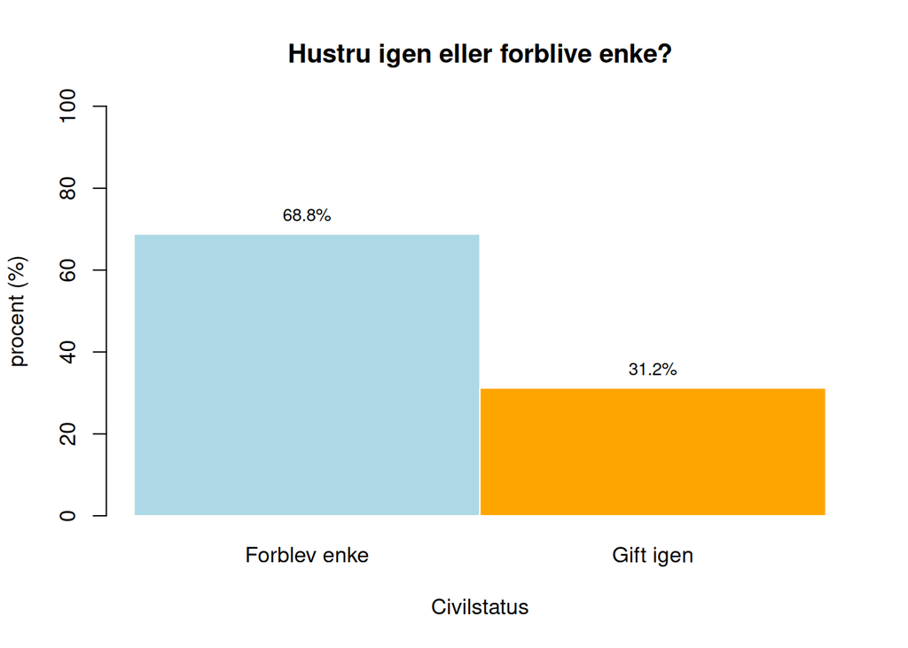

```r
#Laver et barplot
gift_eller_enke_bp<-barplot(as.matrix(gee_procenter),
        width = 0.5,
        names.arg= c("Forblev enke","Gift igen"),
        border = c("white"),
        col = c("lightblue", "orange"),
        ylim = c(0,100),
        beside = TRUE,
        main="Hustru igen eller forblive enke?",
        xlab="Civilstatus",
        ylab="procent (%)"
        )

text(x = gift_eller_enke_bp,
     y = as.matrix(gee_procenter),
     labels = paste0(round(gee_procenter, 1), "%"),
     pos = 3,
     cex = 0.8)
```

#Hvordan fordelte kvinderne der forblev enker og kvinderne der valgte at gifte sig igen henover de tre perioder.

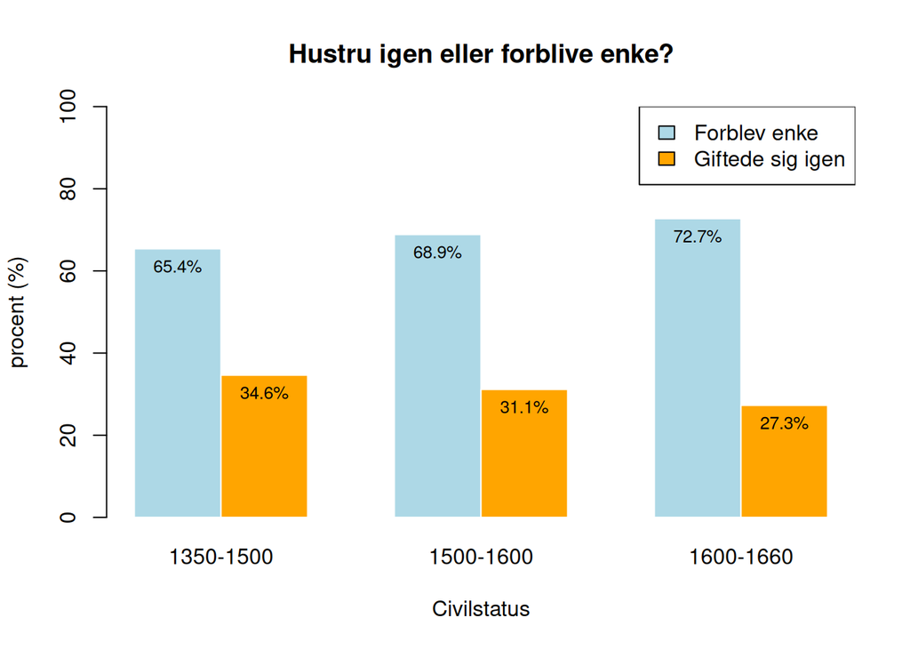

```r
fegi_tal<-table(df_enker$Gift_eller_Enke, df_enker$Periode) #for den til at tælle hvor mange som forblev enker eller giftede sig igen i forhold til de forskellige perioder

fegi_procent<-prop.table(table(df_enker$Gift_eller_Enke, df_enker$Periode), margin = 2)*100 #laver det om til procenter

forblev_enke_eller_gift_igenbp<-barplot(as.matrix(fegi_procent),
        width = 0.5,
        border = c("white"),
        col = c("lightblue", "orange"),
        ylim = c(0,100),
        beside = TRUE,
        main="Hustru igen eller forblive enke?",
        xlab="Civilstatus",
        ylab="procent (%)"
        )

legend(x = "topright",
               legend = c("Forblev enke", "Giftede sig igen"),
               fill = c("lightblue", "orange"))


text(x = forblev_enke_eller_gift_igenbp,
     y = as.matrix(fegi_procent),
     labels = paste0(round(as.matrix(fegi_procent), 1), "%"),
     pos = 1,
     cex = 0.8)
```

## Graf for antal af første gangs gifte, 2. gangs gifte, 3 gangs gifte og 4. gangs gifte.

benyttede mig af chatgpt til at få hjælp til ifelse funktionen

```r
#først laver jeg mine kategoriske værdier binære, så det er nemmere at regne ud hvor mange der blev gift de forskellige antal gange

df_enker$gift_eller_enke_binary <- ifelse(df_enker$Gift_eller_Enke == "Forblev_Enke", 0, 1)

df_enker$gift_eller_enke2_binary <- ifelse(
  is.na(df_enker$Gift_eller_enke2), NA,
  ifelse(df_enker$Gift_eller_enke2 == "Forblev_Enke", 0, 1)
)

df_enker$overlevede_sin_mand_binary <- ifelse(
  is.na(df_enker$Overlevede_sin_mand), NA,
  ifelse(df_enker$Overlevede_sin_mand == "TRUE" , 1, 0)
)


df_enker$overlevede_sin_3mand_binary <- ifelse(
  is.na(df_enker$Overlevede_sin_3mand), NA,
  ifelse(df_enker$Overlevede_sin_3mand == "TRUE" , 1, 0)
)


df_enker$gift4_binary <- ifelse(
  is.na(df_enker$gift4), NA,
  ifelse(df_enker$gift4 == "TRUE" , 1, 0)
)
```

Her vælger jeg at tilskrive dem som vi ikke ved døde før deres mand eller dem som døde før deres mand at de blev gift 2 gange, de havde ikke valget men de blev jo stadig gift to gange. eksempelvis hvis en kvinde valgte at gifte sig anden gang efter hun blev enke, så ved vi ikke om hun døde inden hendes anden mand så derfor står der NA i kolonnen om hun forblev enke eller gift igen. men der står ukendt i om hun overlevede manden eller ej. det vigtige er at notere sig at ukendt ikke er det samme som NA i det her tilfælle, da jeg havede brug for to måder at skrive NA, en kategorisk og en NA jeg kunne fjerne. NA er i kollonen overlevede_sin_mand altså lig med at det var irrelevant da hun ikke blev gift mere en en gang og ukendt betyder hun blev gift 2 gange men vi ved ikke om hun overlevede sig mand eller ej.

brugte chatgpt til at forklare mig om case_when funktionen. har selv lavet koden.

```r
# her laver jeg en ny kollone kaldet antal bryllupper hvor jeg beder dem om at give antal bryllupper en bestemt værdi hvis rækken opfylder nogle conditions eksempel med den første hvis gift eller enke binary kolonnen er lig med 0 så skal den skrive at de kun oplevede et bryllup i deres liv.

df_enker<- df_enker%>%
  mutate(antal_bryllupper= case_when(gift_eller_enke_binary == 0 ~ 1,
                                     gift_eller_enke_binary == 1 & (gift_eller_enke2_binary == 0 | overlevede_sin_mand_binary == 0)~ 2,
                                     gift_eller_enke_binary == 1 & gift_eller_enke2_binary == 1 & overlevede_sin_3mand_binary == 0 ~ 3,
                                     gift_eller_enke_binary == 1 & gift_eller_enke2_binary == 1 & overlevede_sin_3mand_binary == 1 & gift4_binary == 1 ~ 4,
                                     TRUE ~ NA_real_
                                     ))
```

nu laver jeg en table med dem for at se hvor mange der blev gift de forskellige gange og så udregner jeg procent og plotter det i en graf.

```r
antal_bryllupper_tal<-table(df_enker$antal_bryllupper) #tæller op hvor mange der er af hver



antal_bryllupper_procent<-round(prop.table(antal_bryllupper_tal)*100, 2) #laver det om til procenter
```

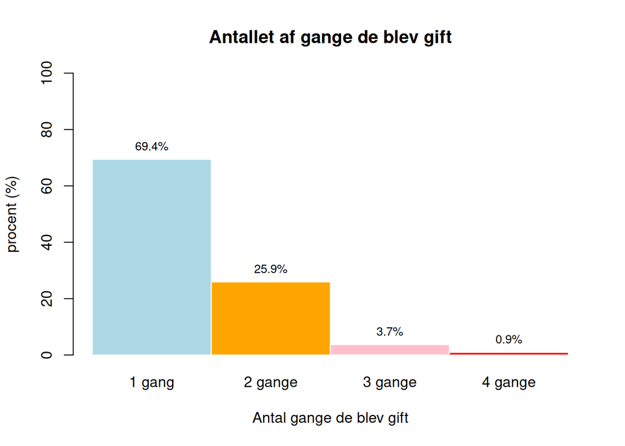

```r
#plotter det ind i en graf nu

bp_bryllupper<-barplot(as.matrix(antal_bryllupper_procent),
        width = 0.5,
        border = c("white"),
        col = c("lightblue", "orange", "pink", "red"),
        ylim = c(0,100),
        names.arg = c("1 gang", "2 gange", "3 gange", "4 gange"),
        beside = TRUE,
        main="Antallet af gange de blev gift",
        xlab="Antal gange de blev gift",
        ylab="procent (%)"
        )

# Vis procenterne oven på søjlerne fik hjælp af chatgpt til koden her
text(x = bp_bryllupper, # skal være med bestemmer hvor teksten skal være i forhold til x-aksen bp er mit barplot, så jeg siger den skal gøre det i forhold til mit barplot
     y = as.matrix(antal_bryllupper_procent), #y bestemmer hvor højt teksten skal være på y aksen, jeg siger den skal være ligeså højt på grafen som mine søjler, ved at give den mine procentværdier som indikator for højden.
     labels = paste0(round(as.matrix(antal_bryllupper_procent), 1), "%"), #labels er funktionen hvor jeg skriver den egentlig tekst der skal stå, paste0 tilføjer et % efter hvert tal. Round runder mine tal ned til 1 decimal.
     pos = 3, #bestemmer hvor teksten skal stå 3 er over søjlerne
     cex = 0.8) #bestemmer skriftstørrelsen
```

## T-test. Sammenligner den gennemsnitslige alder for kvinder der valgte at forblive enke og kvinder der valgte at gifte sig igen.

først fjern na. omit fra de kolonner jeg skal bruge hvilket er fødsel og årstal enke 1.

```r
#Først fjerne jeg med Na.omit alle de rækker hvor der er manglende datapunkter

df_enkealder_clean<-na.omit(df_enker[,c("Født", "Enke1_årstal", "Gift_eller_Enke")])
```

dernæst skal jeg minus årstal enke 1 med fødsel og lave en ny række med dem.

```r
#her tilføjer jeg en kolonne hvor jeg regner ud hvad alder kvinderne havde da de blev enke
df_enkealder<-df_enkealder_clean%>%
  mutate(alder_som_enke= as.numeric(`Enke1_årstal`)-  as.numeric(`Født`))
```

så skal jeg tjekke at jeg rent faktisk kan bruge en t-test ved at tjekke om normalfordeling det gør jeg visuelt ved hjælp af et histogram og statistisk gennem en shapiro-wilk test

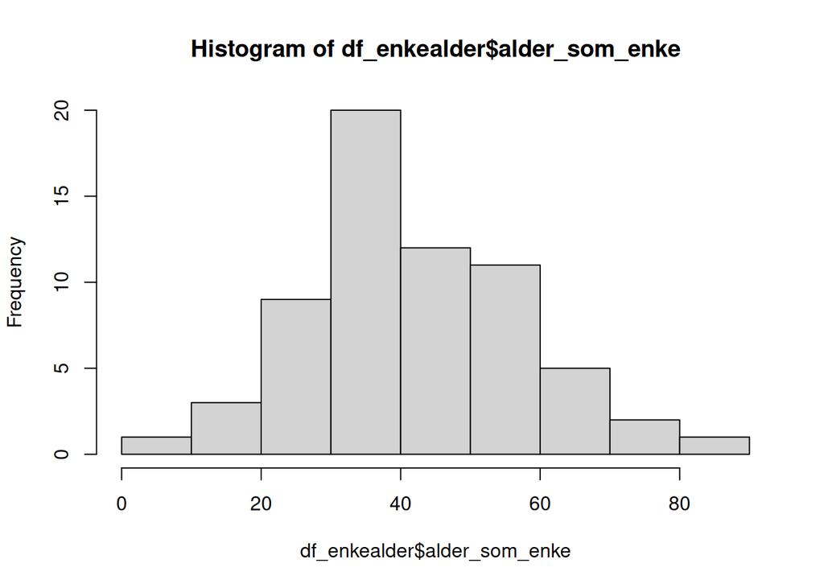

```r
hist(df_enkealder$alder_som_enke)
```

hist(df_enkealder$alder_som_enke[df_enkealder$Gift_eller_Enke==“Gift_igen”]) hist(df_enkealder$alder_som_enke[df_enkealder$Gift_eller_Enke==“Forblev_enke”]) her er det hvis jeg skal lave et histogram for hve gruppe. ca. det samme for shapiro wilk-testen.

det var okay at gøre det for dem samlet, man kan godt gøre det for dem individuelt men så skal jeg have flere datapunkter

```r
shapiro.test(df_enkealder$alder_som_enke)
```

```
##
##  Shapiro-Wilk normality test
##
## data:  df_enkealder$alder_som_enke
## W = 0.98586, p-value = 0.6762
```

tolk resultat: p-værdi større end 0,05: Du finder ikke statistisk evidens for afvigelse fra normalfordeling. p-værdi mindre end 0,05: Der er statistisk evidens for afvigelse fra normalfordeling.

Tjekker der ikke er nogle vilde outliers

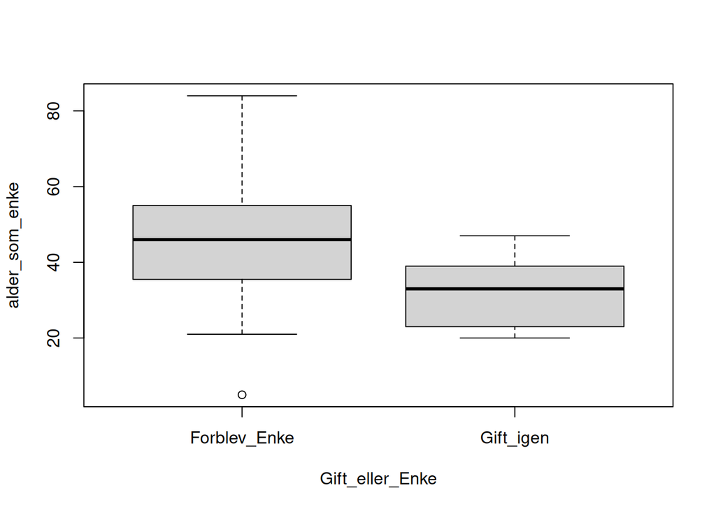

```r
boxplot(alder_som_enke ~ Gift_eller_Enke,
        data = df_enkealder)
```

bruge t-test funktionen til at sammenligne den gennemsnitslige alder med de to grupper. Jeg laver en welch two sample t-test fordi jeg gerne vil undersøge gennemsnitalderen for to uafhængige grupper

```r
t.test(alder_som_enke~Gift_eller_Enke, data= df_enkealder)
```

```
##
##  Welch Two Sample t-test
##
## data:  alder_som_enke by Gift_eller_Enke
## t = 4.2847, df = 45.407, p-value = 9.4e-05
## alternative hypothesis: true difference in means between group Forblev_Enke and group Gift_igen is not equal to 0
## 95 percent confidence interval:
##   7.169177 19.882137
## sample estimates:
## mean in group Forblev_Enke    mean in group Gift_igen
##                   45.70213                   32.17647
```

Ergo jeg accepterer den alternative hypotese og siger der er en signifikant forskel på gennemsnits alderen for de to grupper. dem der forblev enker var i gennemsnit ældre end dem der valgte at gifte sig igen. så alder kan sige at have indvirkning på det.

##regression. Er der sammenhæng mellem længde på 1. ægteskab og valget om at forblive enke eller gifte sig igen.

Kan længde på 1. ægteskab siges at gøre dig mere tilbøjelig til at blive gift igen eller forblive enke?

havde selv na. omit funktionen men fik hjælp af chatgpt til at finde ud af mere specifikt at jeg skulle kalde det NA og ikke Na i min database, for ellers virkede koden ikke og hvordan jeg gjorde det så den kun fjernede NA’s fra to kolonner.

```r
#fjerner rækker med NA

df_enke_clean<-na.omit(df_enker[,c("Længde_på_1", "Gift_eller_Enke")])
```

visualiserer så jeg kan undersøge om der muligvis er en signifikant sammenhæng mellem længde på 1 ægteskab og om de forblev enker eller giftede sig igen.

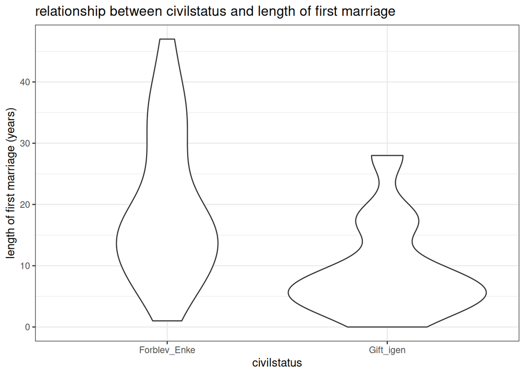

```r
ggplot(df_enke_clean, aes(x=Gift_eller_Enke, y=Længde_på_1))+
  geom_violin()+
  theme_bw()+
  labs(title = "relationship between civilstatus and length of first marriage", x="civilstatus", y="length of first marriage (years)")
```

laver også lige et boxplot for god ordens skyld

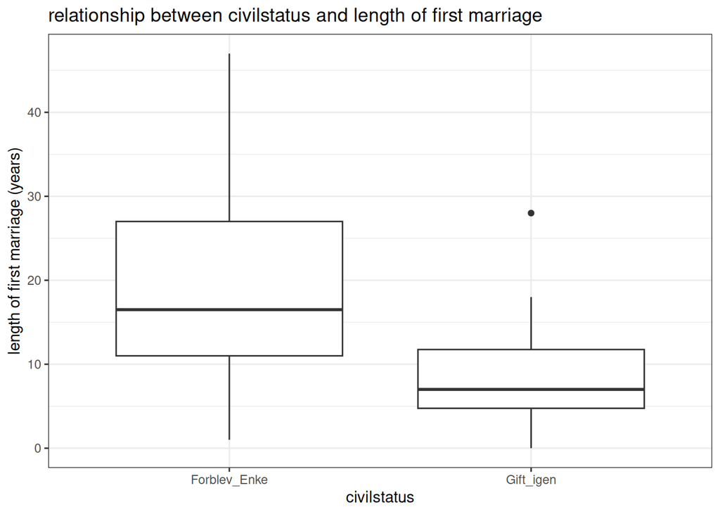

```r
ggplot(df_enke_clean, aes(x=Gift_eller_Enke, y=Længde_på_1))+
  geom_boxplot()+
  theme_bw()+
  labs(title = "relationship between civilstatus and length of first marriage", x="civilstatus", y="length of first marriage (years)")
```

som det ser ud ligenu er der en overvægt af kvinder som havde et kortere ægteskab, der valgte at gifte sig igen modsat kvinder med et langt ægteskab.

##logistic regression. Er der sammenhæng mellem længde på 1. ægteskab og valget om at forblive enke eller gifte sig igen.

havde selv na. omit funktionen men fik hjælp af chatgpt til at finde ud af mere specifikt at jeg skulle kalde det NA og ikke Na i min database, for ellers virkede koden ikke og hvordan jeg gjorde det så den kun fjernede NA’s fra to kolonner.

```r
#fjerner rækker med NA, for at tilføje flere rækker skal jeg bare sætte komme og skrive den nye kolonne i ""

df_enke_clean <- na.omit(df_enker[,c("Længde_på_1", "Gift_eller_Enke", "Antal_levendebrødre_efter_1enkestatus", "Antal_levendesøstre_efter_1enkestatus")])
```

```r
#Her splitter jeg mit datasæt op i et 80% træningssæt og et 20% testsæt så jeg har noget min model kan træne på og noget jeg så kan teste min model af på i forhold til rigtige observationer.

split <- sample.split(1:nrow(df_enke_clean), SplitRatio = 0.8)

train_reg <- subset(df_enke_clean, split == "TRUE")
test_reg <- subset(df_enke_clean, split == "FALSE")
```

```r
#Nu laver jeg den logistiske model

train_reg$Gift_eller_Enke <- as.factor(train_reg$Gift_eller_Enke) #Jeg skal lige lave gift eller enke fra en charachter variable til noget som den logistiske model kan arbejde udfra derfor laver jeg den til en faktor fik her hjælp fra chatgpt til at finde den her kode/funktion
test_reg$Gift_eller_Enke <- as.factor(test_reg$Gift_eller_Enke)

logistic_model <- glm(Gift_eller_Enke ~ Længde_på_1,
                    data = train_reg,
                    family = "binomial")
logistic_model
```

```
##
## Call:  glm(formula = Gift_eller_Enke ~ Længde_på_1, family = "binomial",
##     data = train_reg)
##
## Coefficients:
## (Intercept)  Længde_på_1
##      1.1723      -0.1978
##
## Degrees of Freedom: 45 Total (i.e. Null);  44 Residual
## Null Deviance:       48.17
## Residual Deviance: 34.89     AIC: 38.89
```

```r
summary(logistic_model)
```

```
##
## Call:
## glm(formula = Gift_eller_Enke ~ Længde_på_1, family = "binomial",
##     data = train_reg)
##
## Coefficients:
##             Estimate Std. Error z value Pr(>|z|)
## (Intercept)  1.17230    0.86826   1.350   0.1770
## Længde_på_1 -0.19779    0.07935  -2.493   0.0127 *
## ---
## Signif. codes:  0 '***' 0.001 '**' 0.01 '*' 0.05 '.' 0.1 ' ' 1
##
## (Dispersion parameter for binomial family taken to be 1)
##
##     Null deviance: 48.170  on 45  degrees of freedom
## Residual deviance: 34.887  on 44  degrees of freedom
## AIC: 38.887
##
## Number of Fisher Scoring iterations: 6
```

for at tilføje faktorer på den her kode skal jeg bare sætte + efter variablen længde på 1, og så skrive den næste variabel jeg vil tjekke om har indflydelse.

Hvordan jeg skal tolke resultatet. Call: Displays the formula and dataset used for the model. Deviance Residuals: Show how well the model fits the data. Smaller values indicate a better fit. Coefficients: Reflect the impact of each predictor on the outcome. Includes standard errors. Significance Codes: Indicate the statistical significance of each predictor (e.g., ‘***’ means highly significant). Dispersion Parameter: Set to 1 for logistic regression, as it uses a binomial distribution. Null Deviance: The model’s deviance without predictors (only the intercept). Residual Deviance: The model’s deviance after adding predictors. A lower value suggests a better fit. AIC: Used to compare models. Lower AIC indicates a better model with fewer unnecessary variables. Fisher Scoring Iterations: The number of steps taken to find the best-fitting model.

nu har jeg så lavet en regressions model baseret på min træningsdata. nu skal jeg teste hvor god den er ud fra mit testdata.

```r
predict_reg <- predict(logistic_model,test_reg,type = "response")

predict_reg <- ifelse(predict_reg >= 0.5, "Gift_igen", "Forblev_enke")
```

kode der ikke virkede fra før

predict_reg <- predict(logistic_model, test_reg, type = “response”)

predict_reg <- as.data.frame(predict_reg) predict_reg

```r
conf_matrix <- table(test_reg$Gift_eller_Enke, predict_reg)


conf_matrix
```

```
##               predict_reg
##                Forblev_enke Gift_igen
##   Forblev_Enke            9         1
##   Gift_igen               1         1
```

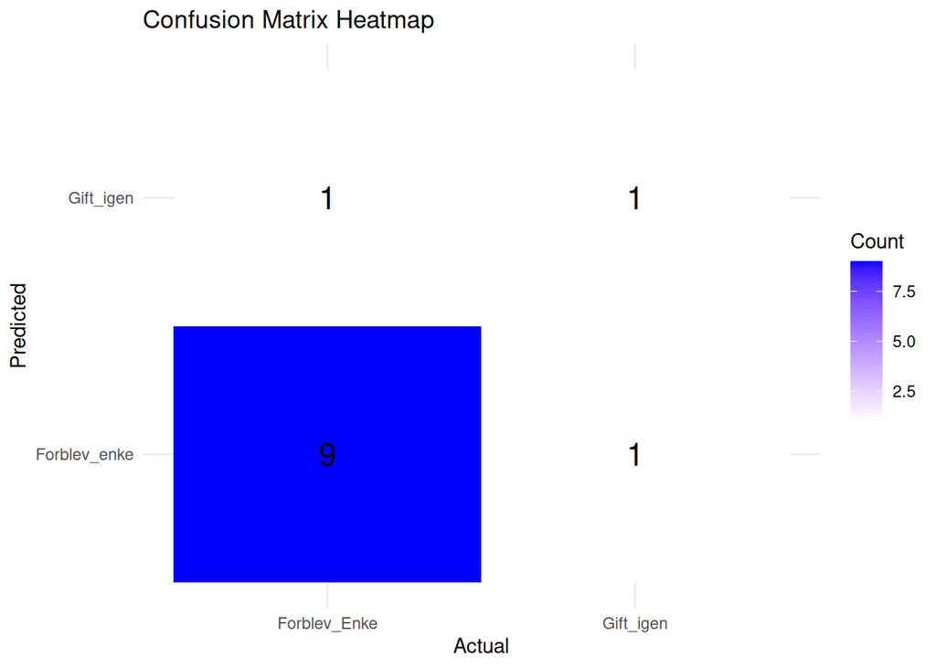

```r
# Reshape the confusion matrix for ggplot2
conf_matrix_melted <- as.data.frame(conf_matrix)
colnames(conf_matrix_melted) <- c("Actual", "Predicted", "Count")

ggplot(conf_matrix_melted, aes(x = Actual, y = Predicted, fill = Count)) +
  geom_tile() +
  geom_text(aes(label = Count), color = "black", size = 6) +  # Add text labels
  scale_fill_gradient(low = "white", high = "blue") +
  labs(title = "Confusion Matrix Heatmap", x = "Actual", y = "Predicted") +
  theme_minimal()
```

laver simple regression. jeg brugte chatgpt til at finde ud af jeg skulle bruge factor funktionen for at fortælle at gift eller enke er kategorisk men så jeg kan bruge det i regressions modellen. jeg fandt også frem til glm funktionen ved at den forklarede mig om forskellige regressionsmodeller.

```r
df_enke_clean$Gift_eller_Enke <- factor(df_enke_clean$Gift_eller_Enke)

model_lgee <- glm(Gift_eller_Enke ~ Længde_på_1, data = df_enke_clean, family=binomial())
summary(model_lgee)
```

```
##
## Call:
## glm(formula = Gift_eller_Enke ~ Længde_på_1, family = binomial(),
##     data = df_enke_clean)
##
## Coefficients:
##             Estimate Std. Error z value Pr(>|z|)
## (Intercept)  0.32135    0.65131   0.493   0.6217
## Længde_på_1 -0.12430    0.05155  -2.411   0.0159 *
## ---
## Signif. codes:  0 '***' 0.001 '**' 0.01 '*' 0.05 '.' 0.1 ' ' 1
##
## (Dispersion parameter for binomial family taken to be 1)
##
##     Null deviance: 59.139  on 57  degrees of freedom
## Residual deviance: 49.585  on 56  degrees of freedom
## AIC: 53.585
##
## Number of Fisher Scoring iterations: 6
```

brug for hjælp til at forstå den her nu når det er kategorisk.

jeg kan ikke lave liniær regression men skal lave en regressionsmodel der gælder for kategorisk variabler læs hjemmeside https://www.cambridge.org/core/books/regression-for-categorical-data/binary-regression-the-logit-model/CF80453FCB0299B40DCE5E736F37933E

og hjælp til at inkluderer andre faktorer som antallet af levende brødre, antallet af levende søstre. antallet af levende børn. alder på kvinden.

giver det mening syntes hun når alder er upræcist for mange.

##spørgsmål til Johanne

- spørg Johanne hvis hende excel og spørg om hun har nogle gode ideer?

lav binærregression og se om du kan forudse om de vælger at gifte sig eller ej. lav logistisk regression

https://www.geeksforgeeks.org/r-language/logistic-regression-in-r-programming/

- spørg Johanne omkring hvordan man bruger python i R for det vil være virkelig rart.
- spørg johanne hvordan jeg cloner så jeg kan gemme på git i min Enker mappe lige nu virker det ikke.
- spørg johanne om mine procenter i prop.table funktionen bliver regnet ud baseret på alle observationer for tænker umiddelbart det ikke giver mening men at der derimod skal udregnes procenter for den indviduelle periode og ikke ale observerede kvinder men ved det ikke helt.

jeg kan putte min punkter ovenpå barplottet og også min standard deviation på et barplot geom_errorbar() se på den her.

- spørg om jeg skal lave en shapiro wilk og histogram i min t-test for de to indviduelle grupper og ikke samlet. Når jeg får mere data så skal jeg lave dem for de to grupper, men ligenu giver det ikke mening at gøre.